# StandR_Demo

Si se identifican variaciones técnicas en los pasos anteriores de QC, antes de realizar cualquier análisis posterior es necesario normalizar los datos para corregir o minimizar dichas variaciones.

El paquete standR ofrece varias opciones de normalización: TMM, RPKM, TPM, CPM, upperquartile y sizefactor.

RPKM y TPM requieren información de la longitud de los genes (agregar la columna genelength al rowData del objeto).

Para TMM, upperquartile y sizefactor, los factores de normalización se almacenan en los metadatos.

En el tutorial se utiliza el método TMM.

```r
datos_tmm <- geomxNorm(datos, method = "TMM")
```

Para evaluar si la normalización eliminó las variaciones no deseadas, se utilizan los gráficos RLE y PCA conjuntamente con los factores de interés.

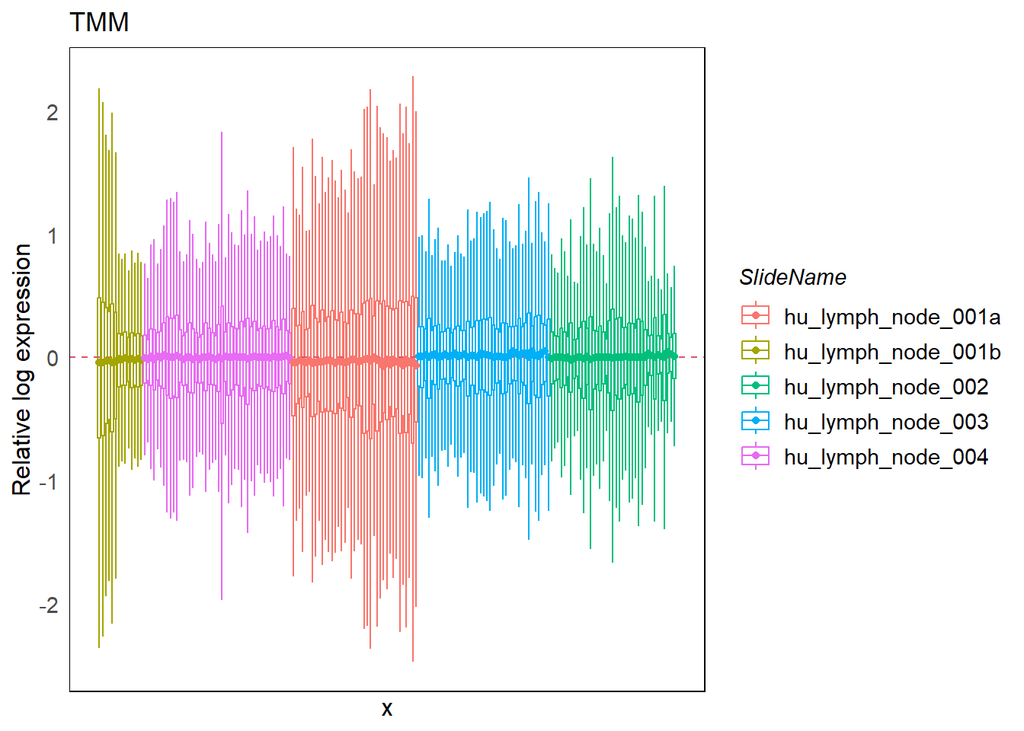

```r
plotRLExpr(datos_tmm, assay = 2, color = SlideName) + ggtitle("TMM")
```

En este caso, del gráfico RLE se observa que la mayoría de las medianas están cerca de cero, lo que indica que gran parte de las variaciones técnicas han sido eliminadas.

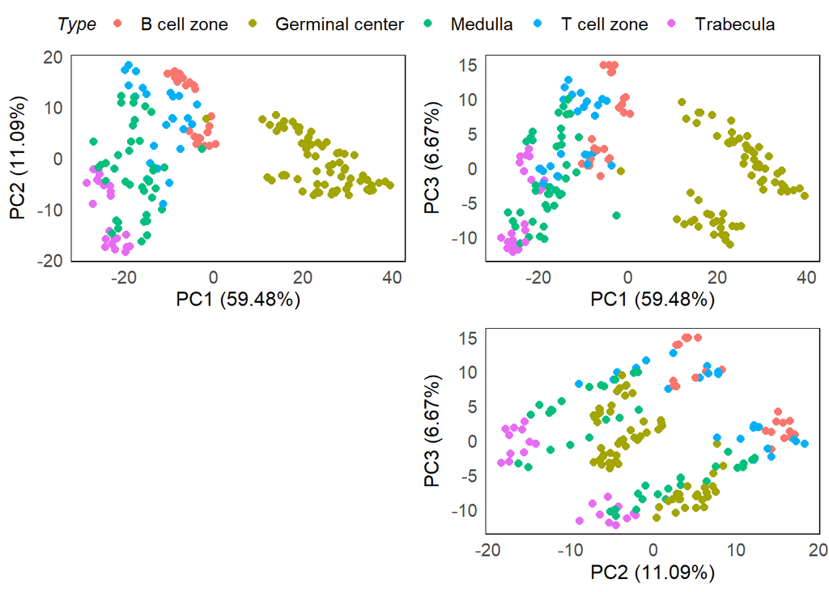

```r
set.seed(100)

datos_tmm <- scater::runPCA(datos_tmm)

pca_results_tmm <- reducedDim(datos_tmm, "PCA")

plotPairPCA(datos_tmm, precomputed = pca_results_tmm, color = Type)
```

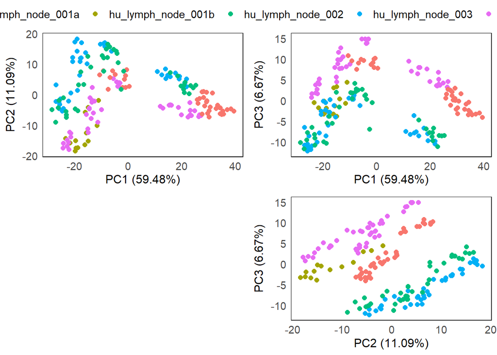

```r
plotPairPCA(datos_tmm, precomputed = pca_results_tmm, color = SlideName)
```

### 4. Corrección por efectos de lote

Cada lámina generalmente solo puede contener unos pocos segmentos de tejido, por lo que es común que los datos de DSP estén afectados por el efecto de lote introducido por las diferentes láminas.

El paquete standR ofrece dos enfoques para corregir efectos de lote: RUV4 y Limma. Otros métodos, como RUVg, están disponibles en la versión en desarrollo.

# RUV4

La función findNCGs permite identificar los NCGs (Negative Control Genes) en los datos. En este caso, como el efecto de lote se debe principalmente a las láminas, se busca identificar NCGs a través de todas las láminas. Por ello, el parámetro batch_name se estableció en “SlideName”, y se seleccionaron los 300 genes menos variables (ordenados por coeficiente de variación) entre las distintas láminas como NCGs. Estos genes se almacenan en el objeto bajo el nombre “NCGs”.

```r
datos <- findNCGs(datos, batch_name = "SlideName", top_n = 300)
```

Se ha creado una columna con los NCGs.

Para la corrección con RUV4, la función requiere 3 parámetros adicionales además del objeto de entrada:

factors: el factor de interés, es decir, la variación biológica que se desea conservar.

NCGs: la lista de genes de control negativo identificados con la función findNCGs.

k: el número de factores no deseados a utilizar. Según la documentación de RUV, se recomienda usar el k más pequeño posible que elimine la variación técnica observada.

Buscamos qué k es la mejor para este análisis.

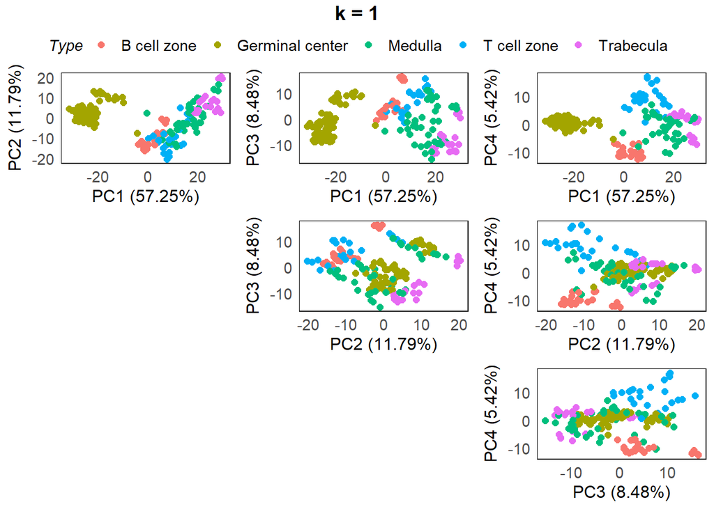

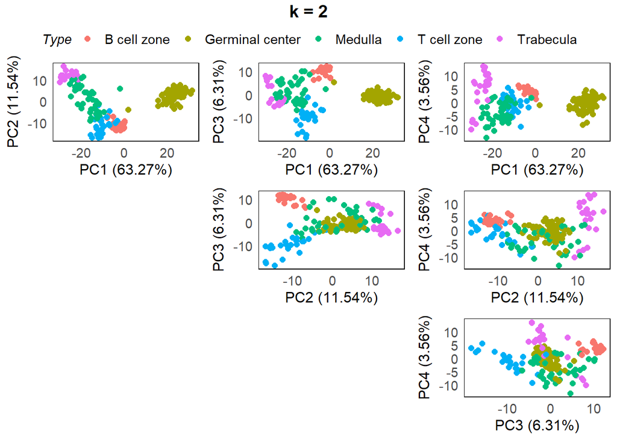

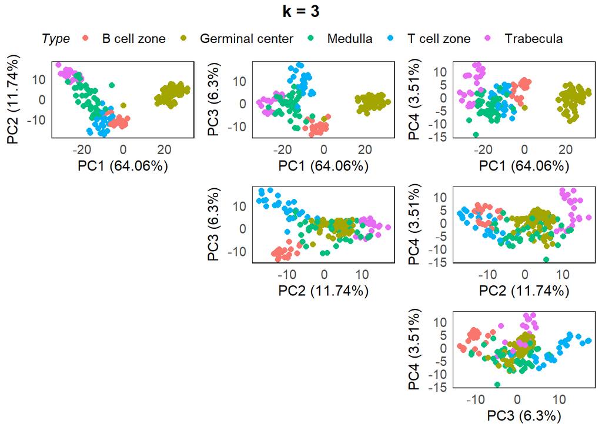

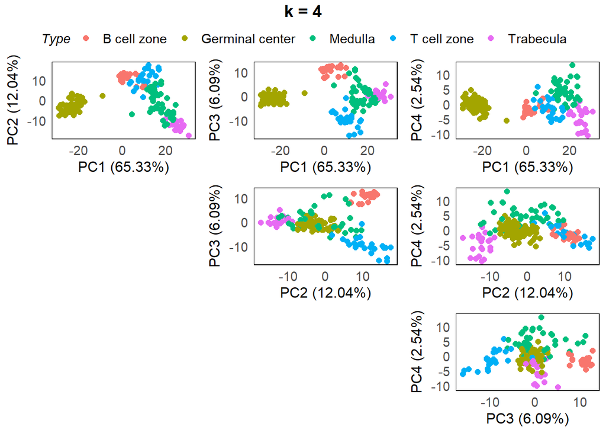

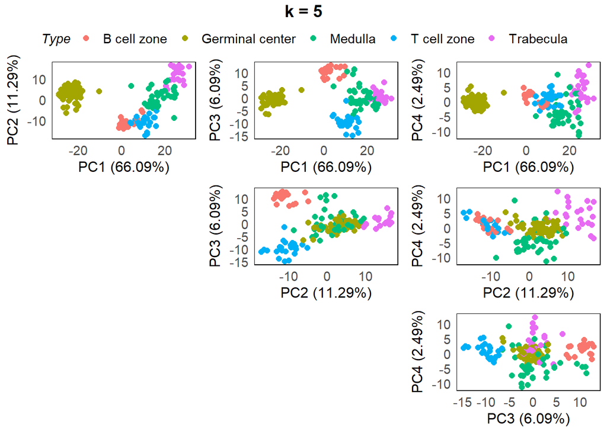

```r
for(i in seq(5)){
  datos_ruv <- geomxBatchCorrection(datos, factors = "Type",
                   NCGs = metadata(datos)$NCGs, k = i)

  print(plotPairPCA(datos_ruv, assay = 2, n_dimension = 4, color = Type, title = paste0("k = ", i)))

}
```

Elejimos k=2 como mejor resultado.

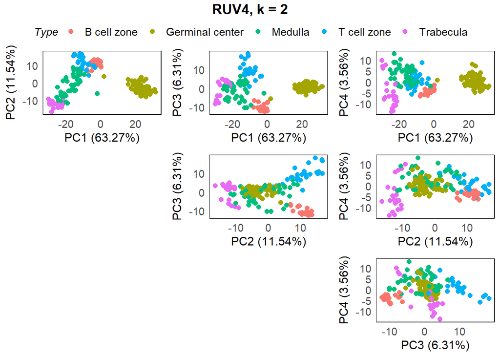

```r
datos_ruv <- geomxBatchCorrection(datos, factors = "Type",
NCGs = metadata(datos)$NCGs, k = 2)

set.seed(100)

datos_ruv <- scater::runPCA(datos_ruv)

pca_results_ruv <- reducedDim(datos_ruv, "PCA")

plotPairPCA(datos_ruv, precomputed = pca_results_ruv, color = Type, title = "RUV4, k = 2", n_dimension = 4)
```

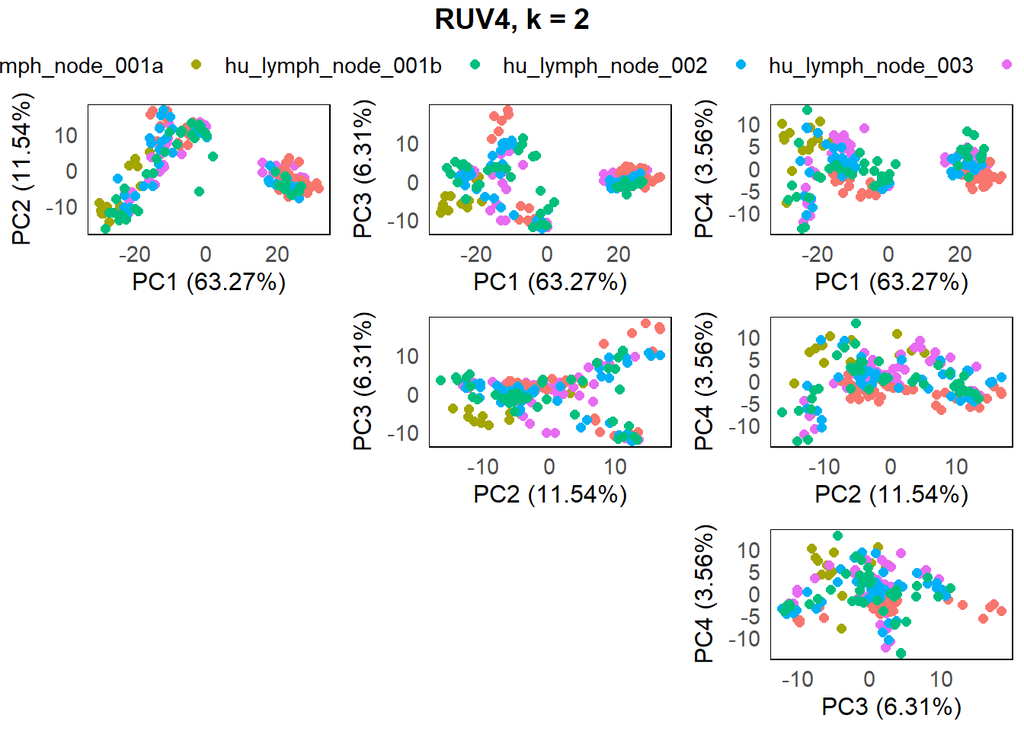

```r
plotPairPCA(datos_ruv, precomputed = pca_results_ruv, color = SlideName, title = "RUV4, k = 2", n_dimension = 4)
```

Se puede observar bastante buena separación entre los distintos tipos celulares. Pero resultados poco claros en cuanto a la distinción de las láminas.